# PM566-Assignment2

Author

YangXu

# Read in the data

```r
library(tidytext)
library(tidyverse)
library(data.table)
library(dplyr)
library(dtplyr)
library(leaflet)
library(ggplot2)
library(data.table)
library(cowplot)
library(viridis)
chs_ind <- data.table::fread("chs_individual.csv")
chs_reg <- data.table::fread("chs_regional.csv")
```

# Data Wrangling

## Merge the data

```r
chs <- merge(chs_ind, chs_reg, by = "townname", all.x = TRUE)
dim(chs_ind)
```

```
[1] 1200   23
```

```r
dim(chs_reg)
```

```
[1] 12 27
```

```r
dim(chs)
```

```
[1] 1200   49
```

From the nrows and ncols, the merge is successful.

## 1. In the case of missing values, impute data using the average amongst individuals with the same values for the “male” and “hispanic” variables. For categorical variables, take the mode.

```r
summary(chs)
```

```
   townname              sid              male            race
 Length:1200        Min.   :   1.0   Min.   :0.0000   Length:1200
 Class :character   1st Qu.: 528.8   1st Qu.:0.0000   Class :character
 Mode  :character   Median :1041.5   Median :0.0000   Mode  :character
                    Mean   :1037.5   Mean   :0.4917
                    3rd Qu.:1554.2   3rd Qu.:1.0000
                    Max.   :2053.0   Max.   :1.0000

    hispanic          agepft           height        weight
 Min.   :0.0000   Min.   : 8.961   Min.   :114   Min.   : 42.00
 1st Qu.:0.0000   1st Qu.: 9.610   1st Qu.:135   1st Qu.: 65.00
 Median :0.0000   Median : 9.906   Median :139   Median : 74.00
 Mean   :0.4342   Mean   : 9.924   Mean   :139   Mean   : 79.33
 3rd Qu.:1.0000   3rd Qu.:10.177   3rd Qu.:143   3rd Qu.: 89.00
 Max.   :1.0000   Max.   :12.731   Max.   :165   Max.   :207.00
                  NA's   :89       NA's   :89    NA's   :89
      bmi            asthma       active_asthma  father_asthma
 Min.   :11.30   Min.   :0.0000   Min.   :0.00   Min.   :0.00000
 1st Qu.:15.78   1st Qu.:0.0000   1st Qu.:0.00   1st Qu.:0.00000
 Median :17.48   Median :0.0000   Median :0.00   Median :0.00000
 Mean   :18.50   Mean   :0.1463   Mean   :0.19   Mean   :0.08318
 3rd Qu.:20.35   3rd Qu.:0.0000   3rd Qu.:0.00   3rd Qu.:0.00000
 Max.   :41.27   Max.   :1.0000   Max.   :1.00   Max.   :1.00000
 NA's   :89      NA's   :31                      NA's   :106
 mother_asthma        wheeze          hayfever         allergy
 Min.   :0.0000   Min.   :0.0000   Min.   :0.0000   Min.   :0.0000
 1st Qu.:0.0000   1st Qu.:0.0000   1st Qu.:0.0000   1st Qu.:0.0000
 Median :0.0000   Median :0.0000   Median :0.0000   Median :0.0000
 Mean   :0.1023   Mean   :0.3313   Mean   :0.1747   Mean   :0.2929
 3rd Qu.:0.0000   3rd Qu.:1.0000   3rd Qu.:0.0000   3rd Qu.:1.0000
 Max.   :1.0000   Max.   :1.0000   Max.   :1.0000   Max.   :1.0000
 NA's   :56       NA's   :71       NA's   :118      NA's   :63
  educ_parent        smoke             pets           gasstove
 Min.   :1.000   Min.   :0.0000   Min.   :0.0000   Min.   :0.0000
 1st Qu.:2.000   1st Qu.:0.0000   1st Qu.:1.0000   1st Qu.:1.0000
 Median :3.000   Median :0.0000   Median :1.0000   Median :1.0000
 Mean   :2.797   Mean   :0.1638   Mean   :0.7667   Mean   :0.7815
 3rd Qu.:3.000   3rd Qu.:0.0000   3rd Qu.:1.0000   3rd Qu.:1.0000
 Max.   :5.000   Max.   :1.0000   Max.   :1.0000   Max.   :1.0000
 NA's   :64      NA's   :40                        NA's   :33
```

[output cut: 48 more lines]

```
     iacid           oacid        total_acids          lon
 Min.   :0.760   Min.   :1.090   Min.   : 1.520   Min.   :-120.7
 1st Qu.:1.835   1st Qu.:2.978   1st Qu.: 4.930   1st Qu.:-118.8
 Median :2.825   Median :4.135   Median : 6.370   Median :-117.7
 Mean   :2.788   Mean   :4.342   Mean   : 6.708   Mean   :-118.3
 3rd Qu.:3.817   3rd Qu.:5.982   3rd Qu.: 9.395   3rd Qu.:-117.4
 Max.   :4.620   Max.   :7.400   Max.   :11.430   Max.   :-116.8

      lat
 Min.   :32.84
 1st Qu.:33.93
 Median :34.10
 Mean   :34.20
 3rd Qu.:34.65
 Max.   :35.49
```

```r
# There is no N/A in male or hispanic. So let's divide chs into four datasets by combination of male and hispanic.
chs_00 <- chs[male == "0" & hispanic == "0",]
chs_01 <- chs[male == "0" & hispanic == "1",]
chs_10 <- chs[male == "1" & hispanic == "0",]
chs_11 <- chs[male == "1" & hispanic == "1",]
# Then impute the missing value in each four categories.
# Now we only consider bmi, fev, smoke and gasstove
# bmi
chs_00$bmi[is.na(chs_00$bmi)] <- mean(chs_00$bmi[!is.na(chs_00$bmi)])
chs_01$bmi[is.na(chs_01$bmi)] <- mean(chs_01$bmi[!is.na(chs_01$bmi)])
chs_10$bmi[is.na(chs_10$bmi)] <- mean(chs_10$bmi[!is.na(chs_10$bmi)])
chs_11$bmi[is.na(chs_11$bmi)] <- mean(chs_11$bmi[!is.na(chs_11$bmi)])
# fev
chs_00$fev[is.na(chs_00$fev)] <- mean(chs_00$fev[!is.na(chs_00$fev)])
chs_01$fev[is.na(chs_01$fev)] <- mean(chs_01$fev[!is.na(chs_01$fev)])
chs_10$fev[is.na(chs_10$fev)] <- mean(chs_10$fev[!is.na(chs_10$fev)])
chs_11$fev[is.na(chs_11$fev)] <- mean(chs_11$fev[!is.na(chs_11$fev)])
# For smoke and gastove, we need to get the mode
# smoke
table(chs_00$smoke) # 0
```

```
  0   1
295  53
```

```r
table(chs_01$smoke) # 0
```

```
  0   1
204  37
```

```r
table(chs_10$smoke) # 0
```

```
  0   1
256  62
```

```r
table(chs_11$smoke) # 0
```

```
  0   1
215  38
```

```r
chs_00$smoke[is.na(chs_00$smoke)] <- 0
chs_01$smoke[is.na(chs_01$smoke)] <- 0
chs_10$smoke[is.na(chs_10$smoke)] <- 0
chs_11$smoke[is.na(chs_11$smoke)] <- 0

# gasstove
table(chs_00$gasstove)  # 1
```

```
  0   1
 94 253
```

```r
table(chs_01$gasstove)  # 1
```

```
  0   1
 44 203
```

```r
table(chs_10$gasstove)  # 1
```

```
  0   1
 70 248
```

```r
table(chs_11$gasstove)  # 1
```

```
  0   1
 47 208
```

```r
chs_00$gasstove[is.na(chs_00$gasstove)] <- 1
chs_01$gasstove[is.na(chs_01$gasstove)] <- 1
chs_10$gasstove[is.na(chs_10$gasstove)] <- 1
chs_11$gasstove[is.na(chs_11$gasstove)] <- 1

# bind them into chs
chs <- rbind(chs_00,chs_01,chs_10,chs_11)
summary(chs)
```

```
   townname              sid              male            race
 Length:1200        Min.   :   1.0   Min.   :0.0000   Length:1200
 Class :character   1st Qu.: 528.8   1st Qu.:0.0000   Class :character
 Mode  :character   Median :1041.5   Median :0.0000   Mode  :character
                    Mean   :1037.5   Mean   :0.4917
                    3rd Qu.:1554.2   3rd Qu.:1.0000
                    Max.   :2053.0   Max.   :1.0000

    hispanic          agepft           height        weight
 Min.   :0.0000   Min.   : 8.961   Min.   :114   Min.   : 42.00
 1st Qu.:0.0000   1st Qu.: 9.610   1st Qu.:135   1st Qu.: 65.00
 Median :0.0000   Median : 9.906   Median :139   Median : 74.00
 Mean   :0.4342   Mean   : 9.924   Mean   :139   Mean   : 79.33
 3rd Qu.:1.0000   3rd Qu.:10.177   3rd Qu.:143   3rd Qu.: 89.00
 Max.   :1.0000   Max.   :12.731   Max.   :165   Max.   :207.00
                  NA's   :89       NA's   :89    NA's   :89
      bmi            asthma       active_asthma  father_asthma
 Min.   :11.30   Min.   :0.0000   Min.   :0.00   Min.   :0.00000
 1st Qu.:15.96   1st Qu.:0.0000   1st Qu.:0.00   1st Qu.:0.00000
 Median :17.81   Median :0.0000   Median :0.00   Median :0.00000
 Mean   :18.50   Mean   :0.1463   Mean   :0.19   Mean   :0.08318
 3rd Qu.:19.99   3rd Qu.:0.0000   3rd Qu.:0.00   3rd Qu.:0.00000
 Max.   :41.27   Max.   :1.0000   Max.   :1.00   Max.   :1.00000
                 NA's   :31                      NA's   :106
 mother_asthma        wheeze          hayfever         allergy
 Min.   :0.0000   Min.   :0.0000   Min.   :0.0000   Min.   :0.0000
 1st Qu.:0.0000   1st Qu.:0.0000   1st Qu.:0.0000   1st Qu.:0.0000
 Median :0.0000   Median :0.0000   Median :0.0000   Median :0.0000
 Mean   :0.1023   Mean   :0.3313   Mean   :0.1747   Mean   :0.2929
 3rd Qu.:0.0000   3rd Qu.:1.0000   3rd Qu.:0.0000   3rd Qu.:1.0000
 Max.   :1.0000   Max.   :1.0000   Max.   :1.0000   Max.   :1.0000
 NA's   :56       NA's   :71       NA's   :118      NA's   :63
  educ_parent        smoke             pets           gasstove
 Min.   :1.000   Min.   :0.0000   Min.   :0.0000   Min.   :0.0000
 1st Qu.:2.000   1st Qu.:0.0000   1st Qu.:1.0000   1st Qu.:1.0000
 Median :3.000   Median :0.0000   Median :1.0000   Median :1.0000
 Mean   :2.797   Mean   :0.1583   Mean   :0.7667   Mean   :0.7875
 3rd Qu.:3.000   3rd Qu.:0.0000   3rd Qu.:1.0000   3rd Qu.:1.0000
 Max.   :5.000   Max.   :1.0000   Max.   :1.0000   Max.   :1.0000
 NA's   :64
```

[output cut: 48 more lines]

```
     iacid           oacid        total_acids          lon
 Min.   :0.760   Min.   :1.090   Min.   : 1.520   Min.   :-120.7
 1st Qu.:1.835   1st Qu.:2.978   1st Qu.: 4.930   1st Qu.:-118.8
 Median :2.825   Median :4.135   Median : 6.370   Median :-117.7
 Mean   :2.788   Mean   :4.342   Mean   : 6.708   Mean   :-118.3
 3rd Qu.:3.817   3rd Qu.:5.982   3rd Qu.: 9.395   3rd Qu.:-117.4
 Max.   :4.620   Max.   :7.400   Max.   :11.430   Max.   :-116.8

      lat
 Min.   :32.84
 1st Qu.:33.93
 Median :34.10
 Mean   :34.20
 3rd Qu.:34.65
 Max.   :35.49
```

There is no more N/As in these variables ## 2. Create a new categorical variable named “obesity_level” using the BMI measurement (underweight BMI<14; normal BMI 14-22; overweight BMI 22-24; obese BMI>24).

```r
chs$obesity_level <- as.factor (ifelse(chs$bmi < 14, 'underweight',
                                ifelse(chs$bmi < 22, 'normal',
                                ifelse(chs$bmi < 24, 'overweight','obese' ))))

# create a summary table that contains the minimum BMI, maximum BMI, and the total number of observations per category.
chs %>%
  group_by(obesity_level) %>%
  summarize(min_bmi = min(bmi),
            max_bmi = max(bmi),
            Count = n()) %>%
  knitr::kable()
```

| obesity_level | min_bmi | max_bmi | Count |
| --- | --- | --- | --- |
| normal | 14.00380 | 21.96387 | 975 |
| obese | 24.00647 | 41.26613 | 103 |
| overweight | 22.02353 | 23.99650 | 87 |
| underweight | 11.29640 | 13.98601 | 35 |

## 3. Create another categorical variable named “smoke_gas_exposure” that summarizes “Second Hand Smoke” and “Gas Stove.” The variable should have four categories in total.

```r
chs$smoke_gas_exposure <- as.factor(fifelse(chs$smoke == 1,
                                            fifelse(chs$gasstove == 1, "smoke_gas", "smoke", na=NA) ,
                                            fifelse(chs$gasstove == 1, "gas", "neither", na=NA), na=NA))
summary(chs$smoke_gas_exposure)
```

```
      gas   neither     smoke smoke_gas
      791       219        36       154
```

## 4. Create four summary tables showing the average (or proportion, if binary) and sd of “Forced expiratory volume in 1 second (ml)” (an asthma indicator) by town, sex, obesity level, and “smoke_gas_exposure.”

```r
# by town
fev_town <- chs[ , .(
  mean_fev = mean(fev, na.rm = TRUE),
  sd_fev = sd(fev, na.rm = TRUE),
  prop_asthma = sum(asthma==1, na.rm = TRUE)/sum(asthma==1 | asthma==0, na.rm = TRUE),
  sd_asthma = sd(asthma, na.rm = TRUE))
, by = "townname"]
knitr::kable(fev_town)
```

| townname | mean_fev | sd_fev | prop_asthma | sd_asthma |
| --- | --- | --- | --- | --- |
| Alpine | 2087.101 | 291.1768 | 0.1134021 | 0.3187308 |
| Atascadero | 2075.897 | 324.0935 | 0.2551020 | 0.4381598 |
| Lake Elsinore | 2038.849 | 303.6956 | 0.1263158 | 0.3339673 |
| Lake Gregory | 2084.700 | 319.9593 | 0.1515152 | 0.3603750 |
| Lancaster | 2003.044 | 317.1298 | 0.1649485 | 0.3730620 |
| Lompoc | 2034.354 | 351.0454 | 0.1134021 | 0.3187308 |
| Long Beach | 1985.861 | 319.4625 | 0.1354167 | 0.3439642 |
| Mira Loma | 1985.202 | 324.9634 | 0.1578947 | 0.3665767 |
| Riverside | 1989.881 | 277.5065 | 0.1100000 | 0.3144660 |
| San Dimas | 2026.794 | 318.7845 | 0.1717172 | 0.3790537 |
| Santa Maria | 2025.750 | 312.1725 | 0.1340206 | 0.3424442 |
| Upland | 2024.266 | 343.1637 | 0.1212121 | 0.3280346 |

```r
# by sex
fev_sex <- chs[ , .(
  mean_fev = mean(fev, na.rm = TRUE),
  sd_fev = sd(fev, na.rm = TRUE),
  prop_asthma = sum(asthma==1, na.rm = TRUE)/sum(asthma==1 | asthma==0, na.rm = TRUE),
  sd_asthma = sd(asthma, na.rm = TRUE))
, by = "male"]
knitr::kable(fev_sex)
```

| male | mean_fev | sd_fev | prop_asthma | sd_asthma |
| --- | --- | --- | --- | --- |
| 0 | 1958.911 | 311.9181 | 0.1208054 | 0.3261747 |
| 1 | 2103.787 | 307.5123 | 0.1727749 | 0.3783828 |

```r
# by obesity_level
fev_obesity_level <- chs[ , .(
  mean_fev = mean(fev, na.rm = TRUE),
  sd_fev = sd(fev, na.rm = TRUE),
  prop_asthma = sum(asthma==1, na.rm = TRUE)/sum(asthma==1 | asthma==0, na.rm = TRUE),
  sd_asthma = sd(asthma, na.rm = TRUE))
, by = "obesity_level"]
knitr::kable(fev_obesity_level)
```

| obesity_level | mean_fev | sd_fev | prop_asthma | sd_asthma |
| --- | --- | --- | --- | --- |
| normal | 1999.794 | 295.1964 | 0.1401475 | 0.3473231 |
| obese | 2266.154 | 325.4710 | 0.2100000 | 0.4093602 |
| overweight | 2224.322 | 317.4261 | 0.1647059 | 0.3731162 |
| underweight | 1698.327 | 303.3983 | 0.0857143 | 0.2840286 |

```r
# by smoke_gas_exposure
fev_smoke_gas_exposure <- chs[ , .(
  mean_fev = mean(fev, na.rm = TRUE),
  sd_fev = sd(fev, na.rm = TRUE),
  prop_asthma = sum(asthma==1, na.rm = TRUE)/sum(asthma==1 | asthma==0, na.rm = TRUE),
  sd_asthma = sd(asthma, na.rm = TRUE))
, by = "smoke_gas_exposure"]
knitr::kable(fev_smoke_gas_exposure)
```

| smoke_gas_exposure | mean_fev | sd_fev | prop_asthma | sd_asthma |
| --- | --- | --- | --- | --- |
| neither | 2056.693 | 328.7843 | 0.1448598 | 0.3527847 |
| gas | 2022.671 | 319.3449 | 0.1491569 | 0.3564744 |
| smoke | 2055.714 | 295.6475 | 0.1714286 | 0.3823853 |
| smoke_gas | 2024.778 | 300.6313 | 0.1275168 | 0.3346759 |

# Look at the data(EDA)

## The primary questions of interest are:

What is the association between BMI and FEV (forced expiratory volume)? What is the association between smoke and gas exposure and FEV? What is the association between PM2.5 exposure and FEV? Follow the EDA checklist from week 3 and the previous assignment. Be sure to focus on the key variables.

```r
# check the dimensions, headers, footers, variable names and variable types
# dimensions
dim(chs)
```

```
[1] 1200   51
```

```r
# headers
head(chs)
```

```
   townname sid male race hispanic    agepft height weight      bmi asthma
1:   Alpine 835    0    W        0 10.099932    143     69 15.33749      0
2:   Alpine 840    0    W        0  9.965777    146     78 16.63283      0
3:   Alpine 860    0    W        0  9.946612    142     64 14.42715      0
4:   Alpine 865    0    W        0 10.039699    162    140 24.24797      1
5:   Alpine 873    0    W        0  9.804244    140    101 23.42301      0
6:   Alpine 894    0    W        0  9.295003    150     89 17.97980      0
   active_asthma father_asthma mother_asthma wheeze hayfever allergy
1:             0             0             0      0        0       1
2:             0             0             0      0        0       0
3:             0             0             0      0        0       0
4:             1             0             0      1        0       1
5:             0             0             0      0        0       0
6:             0             0             0     NA        1       1
   educ_parent smoke pets gasstove      fev      fvc     mmef pm25_mass
```

[output cut: 27 more lines]

```r
# footers
tail(chs)
```

```
   townname  sid male race hispanic   agepft height weight      bmi asthma
1:   Upland 1799    1    O        1 9.897331    138     75 17.90113      0
2:   Upland 1816    1    W        1 9.631759    134     60 15.18864      0
3:   Upland 1833    1    W        1 9.453799    139     73 17.17397      0
4:   Upland 1839    1    M        1 9.776865    141     85 19.43381      0
5:   Upland 1850    1    O        1 9.338809    143     86 19.11629      0
6:   Upland 1862    1    W        1       NA     NA     NA 19.41148      0
   active_asthma father_asthma mother_asthma wheeze hayfever allergy
1:             0             0             0      0        0       0
2:             0             0             0      0        0       1
3:             0             0             0      1        0       0
4:             0             0             0     NA        1       0
5:             0             0             0      1       NA       1
6:             0             1             0      1        0       0
   educ_parent smoke pets gasstove      fev      fvc     mmef pm25_mass
```

[output cut: 27 more lines]

```r
# variable names and types
str(chs)
```

```
Classes 'data.table' and 'data.frame':  1200 obs. of  51 variables:
 $ townname          : chr  "Alpine" "Alpine" "Alpine" "Alpine" ...
 $ sid               : int  835 840 860 865 873 894 901 905 906 909 ...
 $ male              : int  0 0 0 0 0 0 0 0 0 0 ...
 $ race              : chr  "W" "W" "W" "W" ...
 $ hispanic          : int  0 0 0 0 0 0 0 0 0 0 ...
 $ agepft            : num  10.1 9.97 9.95 10.04 9.8 ...
 $ height            : int  143 146 142 162 140 150 132 142 126 141 ...
 $ weight            : int  69 78 64 140 101 89 67 94 57 68 ...
 $ bmi               : num  15.3 16.6 14.4 24.2 23.4 ...
 $ asthma            : int  0 0 0 1 0 0 0 1 0 0 ...
 $ active_asthma     : int  0 0 0 1 0 0 0 1 0 0 ...
 $ father_asthma     : int  0 0 0 0 0 0 0 0 0 0 ...
 $ mother_asthma     : int  0 0 0 0 0 0 0 1 1 0 ...
 $ wheeze            : int  0 0 0 1 0 NA NA 1 0 0 ...
```

[output cut: 38 more lines]

```r
# key variables
summary(chs$obesity_level)
```

```
     normal       obese  overweight underweight
        975         103          87          35
```

```r
summary(chs$bmi)
```

```
   Min. 1st Qu.  Median    Mean 3rd Qu.    Max.
  11.30   15.96   17.81   18.50   19.99   41.27
```

```r
summary(chs$fev)
```

```
   Min. 1st Qu.  Median    Mean 3rd Qu.    Max.
  984.8  1827.6  2016.4  2030.1  2223.6  3323.7
```

```r
summary(chs$pm25_mass)
```

```
   Min. 1st Qu.  Median    Mean 3rd Qu.    Max.
  5.960   7.615  10.545  14.362  20.988  29.970
```

There is nothing strange about the key variables and no missing values.

## Exploratory graphs

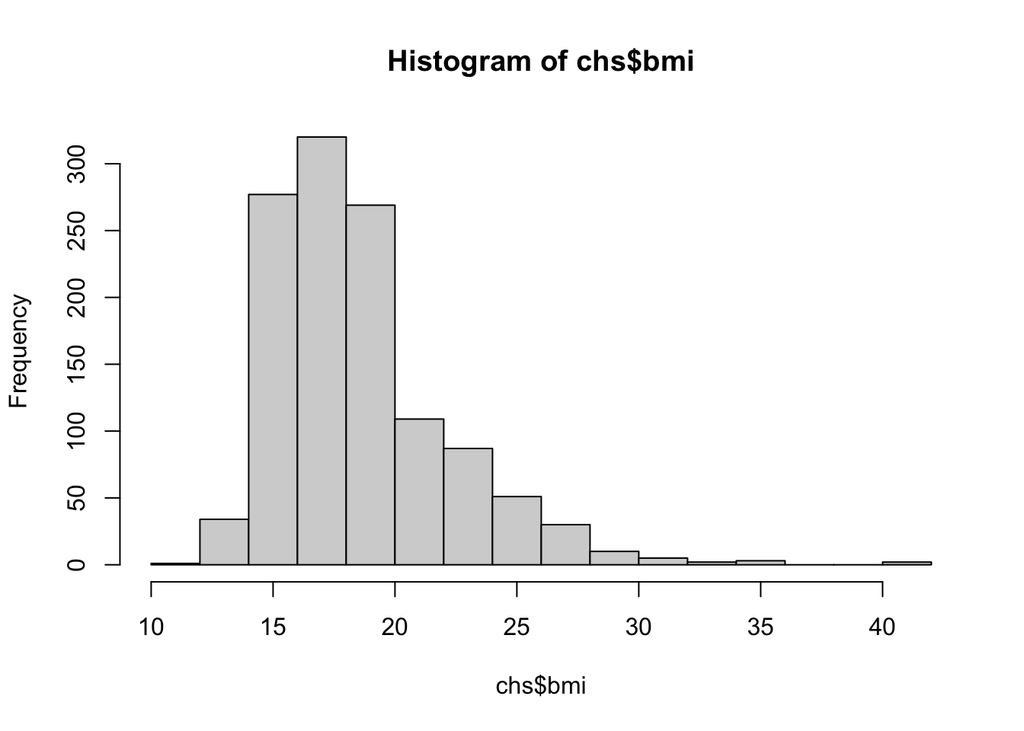

```r
# histograms to look at the distributions over the whole state
hist(chs$bmi)
```

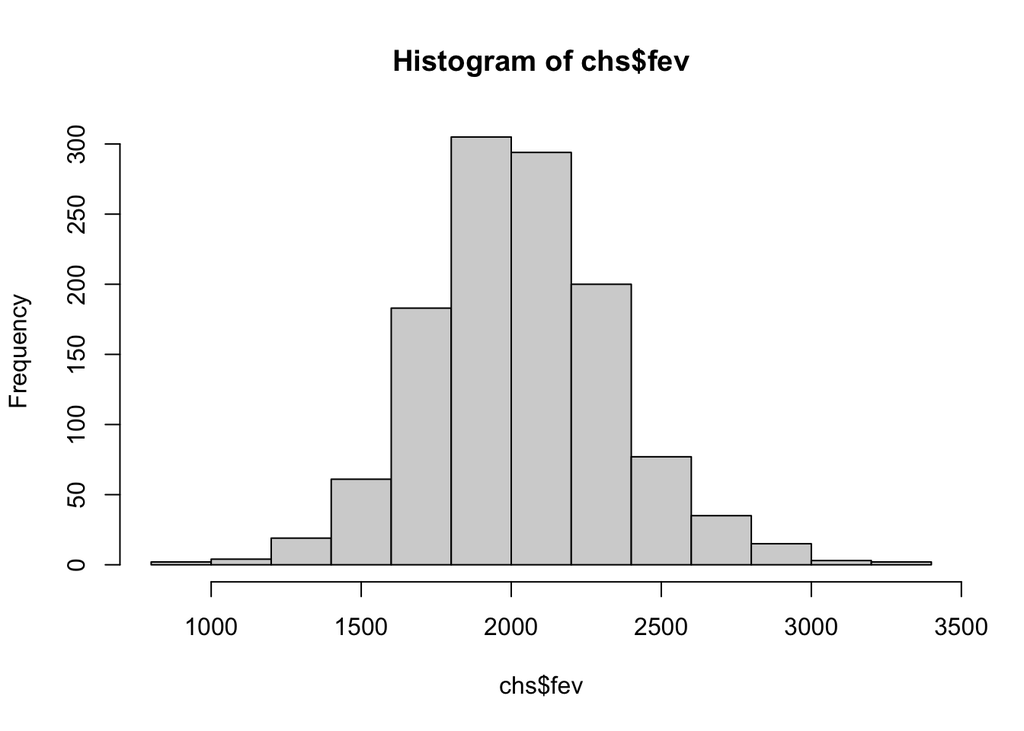

```r
hist(chs$fev)
```

### BMI: there is a long end tail, the distribution of BMI is skewed.

### FEV: The distribution of fev almost follows the normal distribution.

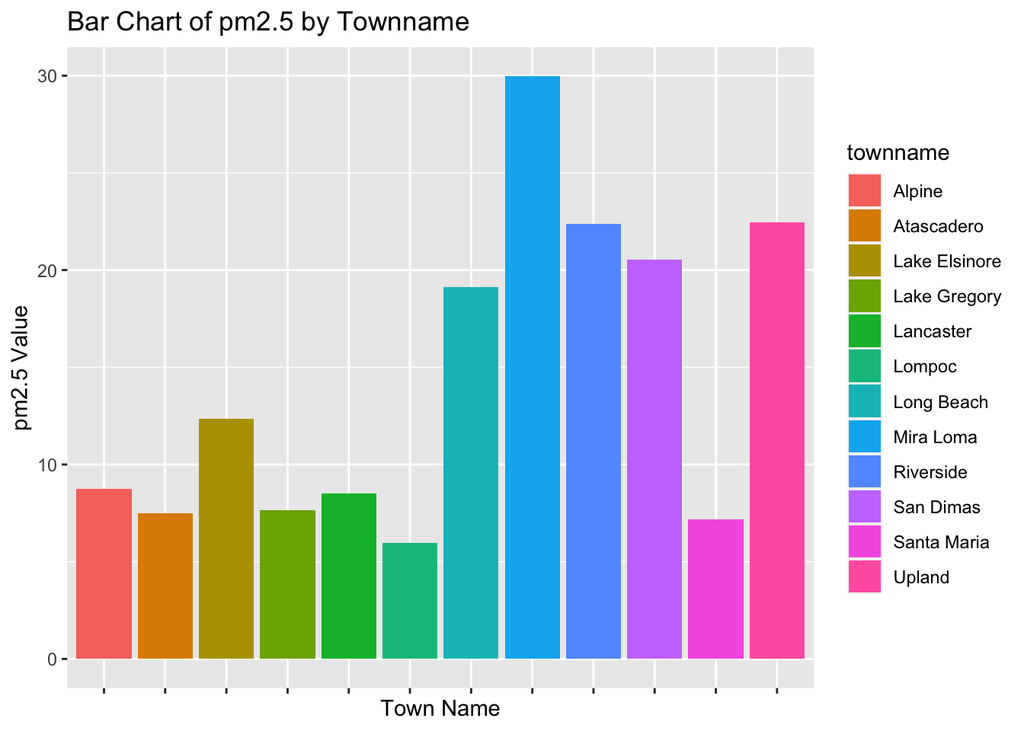

```r
# bar chart
ggplot(chs, aes(x=townname, y=pm25_mass, fill=townname)) +
  geom_bar(stat="identity", position="dodge") +
  labs(title="Bar Chart of pm2.5 by Townname",
       x="Town Name",
       y="pm2.5 Value") +
  theme(axis.text.x=element_blank())
```

### Mira Loma has the highest pm25_mass and Lompoc has the lowest.

# Visualization

Create the following figures and interpret them. Be sure to include easily understandable axes, titles, and legends.

## 1. Facet plot showing scatterplots with regression lines of BMI vs FEV by “townname”.

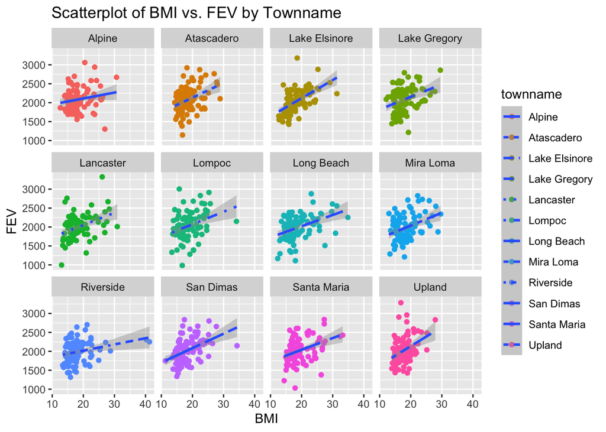

```r
chs %>%
  ggplot(mapping = aes(x = bmi, y = fev)) +
  geom_point(mapping = aes(color = townname)) +
  geom_smooth(method = lm, mapping = aes(linetype = townname)) +
  labs(title = "Scatterplot of BMI vs. FEV by Townname",
       x = "BMI",
       y = "FEV") +
  facet_wrap(~ townname)
```

### In each town, there is a positive association between BMI and FEV.

## 2. Stacked histograms of FEV by BMI category and FEV by smoke/gas exposure. Use different color schemes than the ggplot default.

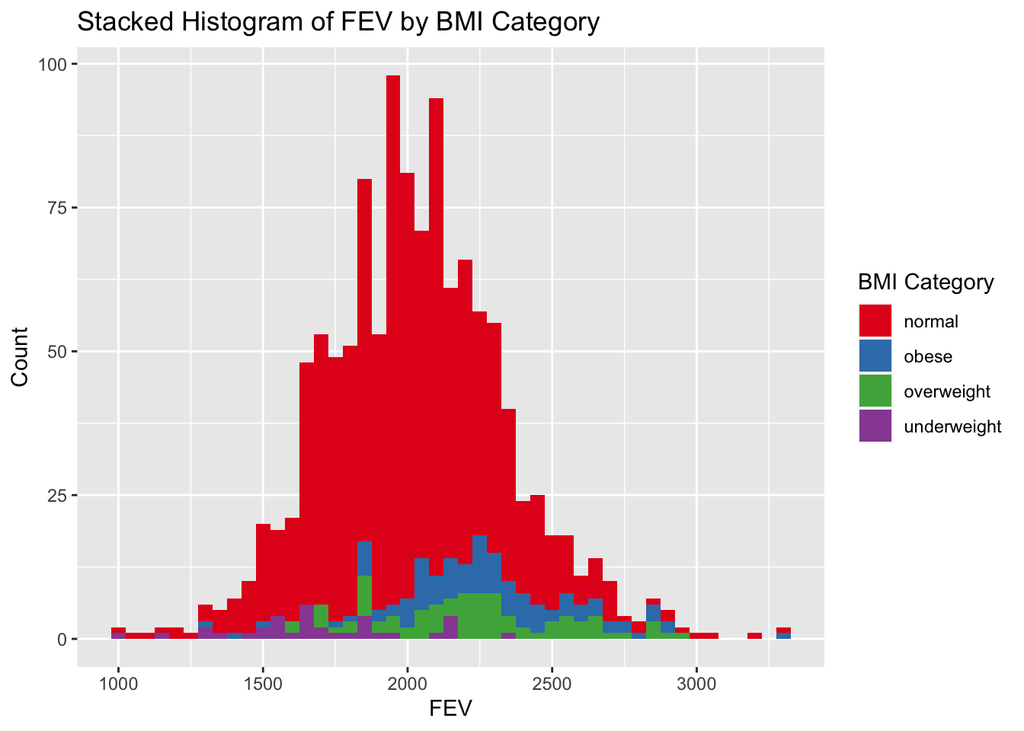

```r
# by BMI category
ggplot(chs, aes(x = fev, fill = obesity_level)) +
  geom_histogram(binwidth = 50, position = "stack") +
  labs(title = "Stacked Histogram of FEV by BMI Category",
       x = "FEV",
       y = "Count") +
  scale_fill_brewer(palette = "Set1", name = "BMI Category")
```

### Underweight population tend to have lower FEV. Overweight and obese population tend to have higher FEV.

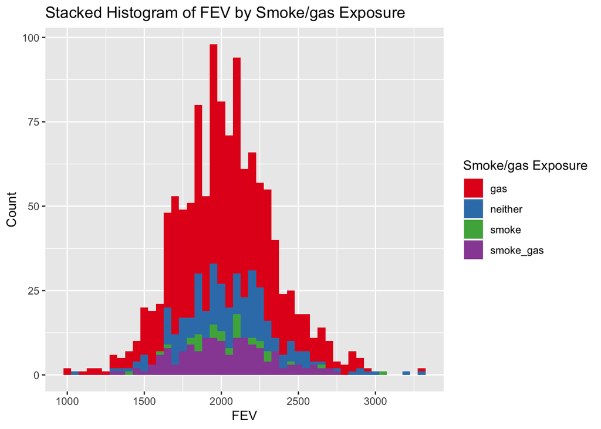

```r
# by smoke/gas exposure
ggplot(chs, aes(x = fev, fill = smoke_gas_exposure)) +
  geom_histogram(binwidth = 50, position = "stack") +
  labs(title = "Stacked Histogram of FEV by Smoke/gas Exposure",
       x = "FEV",
       y = "Count") +
  scale_fill_brewer(palette = "Set1", name = "Smoke/gas Exposure")
```

### These four smoke/gas exposure categories share the similar distributions of FEV.

## 3. Barchart of BMI by smoke/gas exposure.

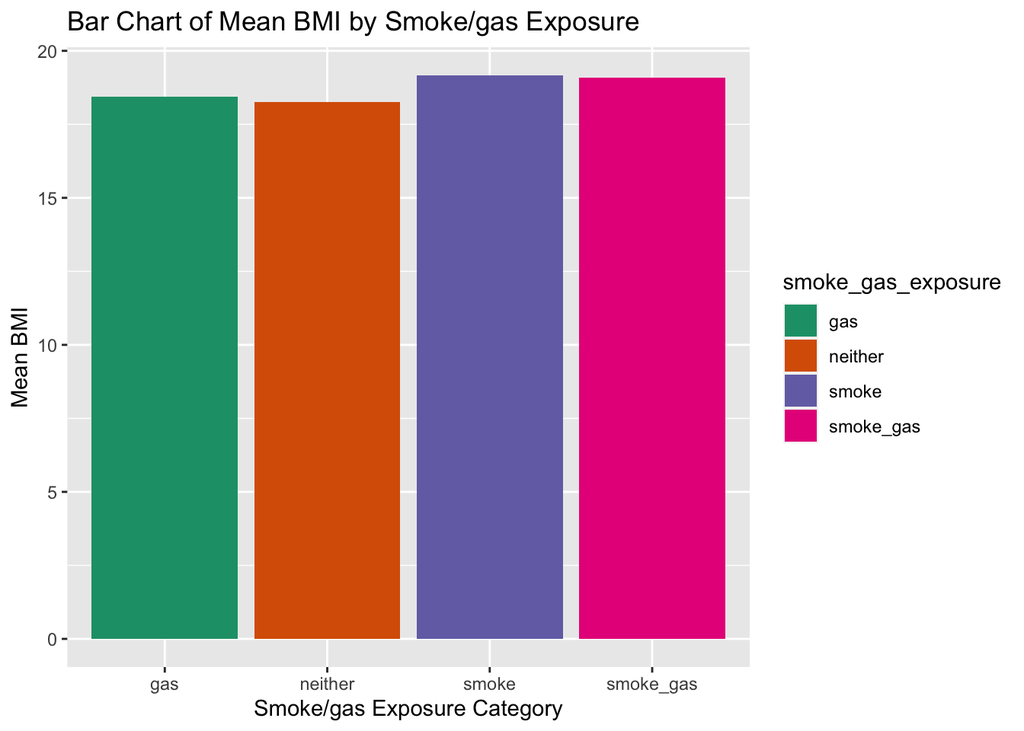

```r
ggplot(chs, aes(x=smoke_gas_exposure, y=bmi, fill=smoke_gas_exposure)) +
  geom_bar(stat = "summary", fun = "mean", position="dodge") +
  labs(title="Bar Chart of Mean BMI by Smoke/gas Exposure",
       x="Smoke/gas Exposure Category",
       y="Mean BMI") +
  scale_fill_brewer(palette="Dark2")
```

### Overall, the difference of mean BMI is very small between each two smoke/gas exposure categories.

## 4.Statistical summary graphs of FEV by BMI and FEV by smoke/gas exposure category.

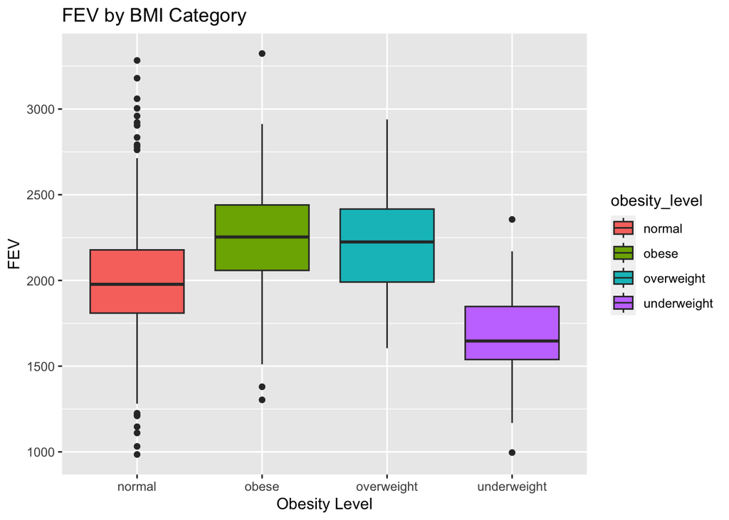

```r
# by BMI Category
chs %>%
  ggplot() +
  geom_boxplot(mapping = aes(x = obesity_level, y = fev, fill = obesity_level)) +
  labs(title = "FEV by BMI Category", x  = "Obesity Level", y = "FEV")
```

### The underweight population has the lowest FEV and the obese population has the highest. The relationship between FEV and BMI categories is positive.

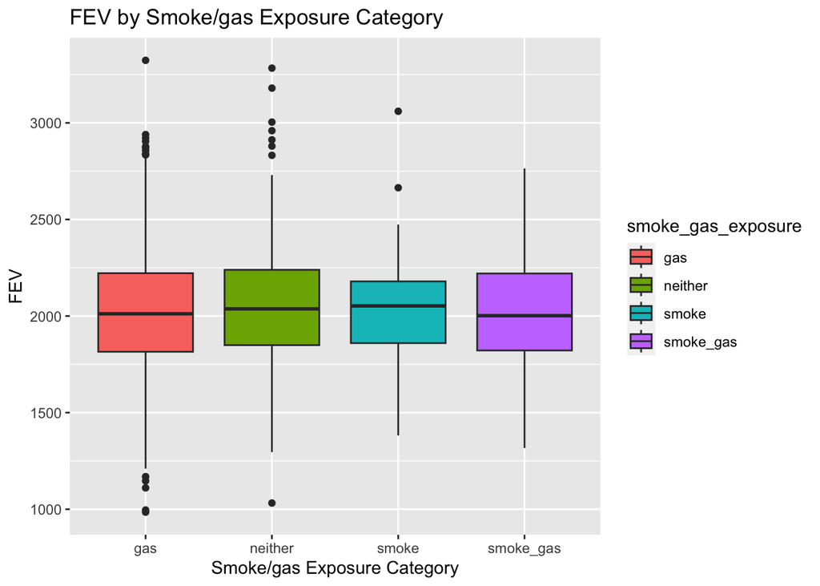

```r
# by smoke/gas exposure
chs %>%
  ggplot() +
  geom_boxplot(mapping = aes(x = smoke_gas_exposure, y = fev, fill = smoke_gas_exposure)) +
  labs(title = "FEV by Smoke/gas Exposure Category ", x  = "Smoke/gas Exposure Category", y = "FEV")
```

### There is no obvious difference of FEV among these four Smoke/gas Exposure categories.

## 5.A leaflet map showing the concentrations of PM2.5 mass in each of the CHS communities.

```r
pal <- colorFactor( palette = "inferno", domain = chs$pm25_mass)

leaflet(chs) %>%
  addProviderTiles('OpenStreetMap') %>%
  addCircleMarkers(lat =~ lat,
             lng =~ lon,
             opacity = 0.5,
             fillOpacity = 0.5, radius = 5, color =~ pal(pm25_mass),
             popup = ~paste("Community: ", townname, "<br>PM2.5 Mass: ", pm25_mass, " µg/m³"),
  ) %>%
  addLegend(position = "bottomleft", pal = pal, values = chs$pm25_mass,
            title = 'Concentrations of PM2.5 mass among CHS communities', opacity = 1
            )
```

[interactive chart not shown]

### The map shows that the communities closer to the downtown area have higher PM2.5_mass.

## 6. Choose a visualization to examine whether PM2.5 mass is associated with FEV.

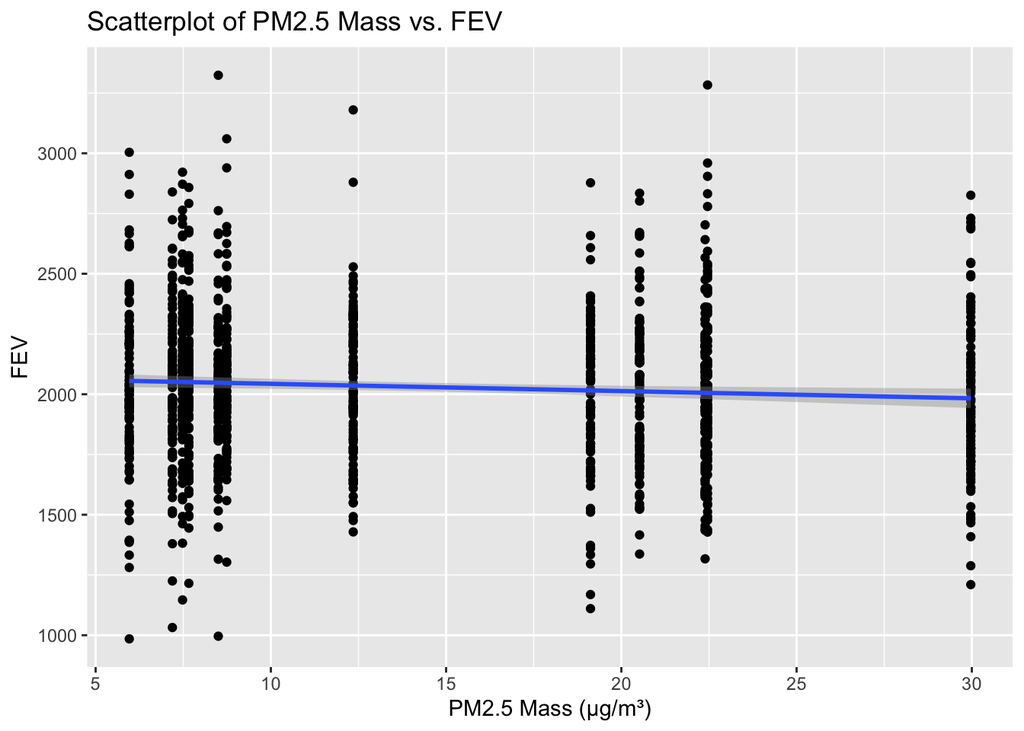

```r
# Since pm25_mass and fev are both numeric variables, we choose scatter plot
ggplot(chs, aes(x = pm25_mass, y = fev)) +
  geom_point() +
  geom_smooth(method = "lm") +
  labs(title = "Scatterplot of PM2.5 Mass vs. FEV",
       x = "PM2.5 Mass (µg/m³)",
       y = "FEV")
```

### We find that pm25_mass only have 12 values, so we can treat it as a categorical variable and make a boxplot.

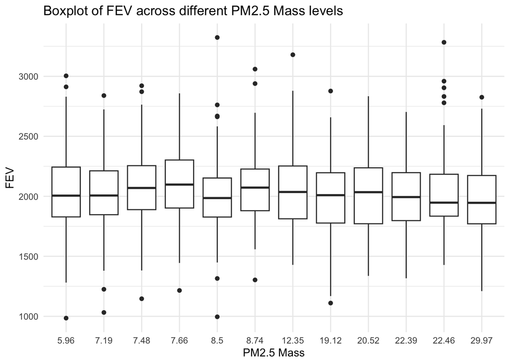

```r
# boxplot
ggplot(chs, aes(x=factor(chs$pm25_mass), y=chs$fev)) +
  geom_boxplot() +
  labs(title="Boxplot of FEV across different PM2.5 Mass levels",
       x="PM2.5 Mass",
       y="FEV") +
  theme_minimal()
```

### From the scatter plot, it seems that PM2.5 mass is slightly negatively associated with FEV. But the association is not obvious in the boxplot.